# A Graph Neural Network (GNN) from Scratch for semantic image segmentation

# Goals :

1. An illustration of GNN for node classification
2. A toy applicaion to skin detection
3. A lecture on Structured Machine Learning

# Author: Romain Raveaux (romain.raveaux@univ-tours.fr)

## This notebook is a follow-up of "A Simple Graph Neural Network from Scratch for graph classification" see the link :

http://romain.raveaux.free.fr/document/TP%20DI%20Graph%20Letter%20Classification%20Student-Correction.html

## Install requirements

- [Network](https://networkx.github.io/)
- [Pytorch](https://pytorch.org/)

# The lecture

The content of the is notebook is based on the following lectures : Supervised Machine Learning for structured input/output: Polytech, Tours

- 1. Introduction to supervised Machine Learning: A probabilistic introduction [PDF](http://romain.raveaux.free.fr/document/courssupervisedmachinelearningRaveaux.pdf)
- 2. Connecting local models : The case of chains [PDF slides](http://romain.raveaux.free.fr/document/Connecting%20local%20models%20the%20case%20of%20chains%20.pdf)
- 3. Connecting local models : Beyond chains and trees.[PDF slides](http://romain.raveaux.free.fr/document/Structured%20Output%20Learning.pdf)
- 4. Machine Learning and Graphs : Introduction and problems [PDF slides](http://romain.raveaux.free.fr/document/cours%20IA%20DI5%20graphs%20introV2.pdf)
- 5. **Graph Neural Networks.** [PDF slides](http://romain.raveaux.free.fr/document/graph%20neural%20networks%20romain%20raveaux.pdf)
- 6. Graph Kernels. [PDF slides](http://romain.raveaux.free.fr/document/graph%20kernel%20romain%20raveaux.pdf)

```python
#load of import
import numpy as np
import matplotlib.image as Image
import matplotlib.pyplot as plt
import networkx as nx
import imageio
from skimage.transform import resize
from skimage.transform import rescale
```

```python
# if needed
#!pip install networkx
#!pip install torch
#!pip install scipy
#!pip install matplotlib
```

# The data sets :

[figure not shown]

The data can be downloaded from :

https://github.com/MinhasKamal/SkinDetector/tree/master/data

# Reading some data. Getting in touch with our data

```
(180, 150, 3)
[ 8  8 10]
```

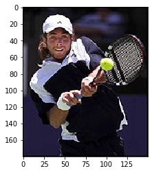

```python
im=Image.imread('./data/image/image (1).jpg')
plt.figure(1)
plt.imshow(im)
print(im.shape)
print(im[5,5])
```

# Rescaling the data such the largest dimension is equal to 100

```
(100, 83, 3)
[0.06017482 0.06017482 0.06801795]
```

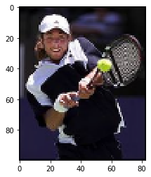

```python
largestdim = 100
rescalefactor=largestdim/float(np.max(im.shape))
im = rescale(im,rescalefactor,multichannel=True)
plt.figure(2)
plt.imshow(im)
print(im.shape)
print(im[5,5])
```

# Reading the mask of skin pixels

```
(180, 150, 3)
[0. 0. 0.]
(100, 83, 3)
[0. 0. 0.]
```

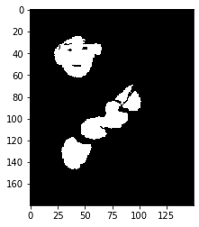

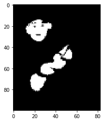

```python
im=Image.imread('./data/mask/mask (1).png')
plt.figure(1)
plt.imshow(im)
print(im.shape)
print(im[5,5])

largestdim = 100
rescalefactor=largestdim/float(np.max(im.shape))
im = rescale(im,rescalefactor,multichannel=True)
plt.figure(2)
plt.imshow(im)
print(im.shape)
print(im[5,5])
```

# Creating a grid graph with RGB features

```python
G=nx.grid_2d_graph(im.shape[0], im.shape[1], periodic=False, create_using=None)
node_label = {}
for x in range(0,im.shape[0]):
    for y in range(0,im.shape[1]):
        node_label[(x,y)]=im[x,y]

nx.set_node_attributes(G,node_label,'feature')

print(len(G.nodes))
print(len(G.edges))
print(G.number_of_nodes())
print(G.number_of_edges())


listnodes = list(G.nodes(data='feature'))
n=listnodes[0]
print(n)
print(n[1])
```

```
8300
16417
8300
16417
((0, 0), array([0., 0., 0.], dtype=float32))
[0. 0. 0.]
```

# Reading an image and returning a graph and the image dimensions

```python
def readimage(file,largestdim):
    im=Image.imread(file)
    im = rescale(im,1,multichannel=True)
    r=im.shape[0]
    c=im.shape[1]
    if np.max([r,c])>largestdim:
        rescalefactor=largestdim/float(np.max([r,c]))
        im = rescale(im,rescalefactor,multichannel=True)#resize(im, (im.shape[0], im.shape[1]))
        r=im.shape[0]
        c=im.shape[1]

    G=nx.grid_2d_graph(im.shape[0], im.shape[1], periodic=False, create_using=None)
    node_label = {}
    for x in range(0,im.shape[0]):
        for y in range(0,im.shape[1]):
            node_label[(x,y)]=im[x,y,0:3]

    nx.set_node_attributes(G,node_label,'feature')
    return G,(r, c)
```

```python
G,(r,c)=readimage('./data/image/image (1).jpg',28)
nodelist, nodesfeatures = map(list, zip(*G.nodes(data='feature')))
print(len(nodelist))
print(len(nodesfeatures))
print(nodelist[60])
print(nodesfeatures[60])
print((r,c))
```

```
644
644
(2, 14)
[0.20229884 0.17564802 0.25133611]
(28, 23)
```

# Reading the mask of skin pixels and returning a graph

```python
def readimagemask(file,r,c):
    im=Image.imread(file)
    im = resize(im, (r, c))
    G=nx.grid_2d_graph(im.shape[0], im.shape[1], periodic=False, create_using=None)
    node_label = {}
    for x in range(0,im.shape[0]):
        for y in range(0,im.shape[1]):
            sumvec=im[x,y].sum()
            if sumvec<0.5:
                node_label[(x,y)]=0
            else:
                node_label[(x,y)]=1

    nx.set_node_attributes(G,node_label,'feature')
    return G
```

```python
G=readimagemask('./data/mask/mask (1).png',28,28)
nodelist, nodesfeatures = map(list, zip(*G.nodes(data='feature')))
print(len(nodelist))
print(len(nodesfeatures))
print(nodelist[660])
print(nodelist[660])
print(nodesfeatures[660])
```

```
784
784
(23, 16)
(23, 16)
0
```

#### Define Dataset Class

Pytorch provides an abstract class representig a dataset, `torch.utils.data.Dataset`. We need to override two methods:

- `__len__` so that `len(dataset)` returns the size of the dataset.
- `__getitem__` to support the indexing such that `dataset[i]` can be used to get i-th sample

```python
import torch.utils.data as data
from torch.utils.data import DataLoader

class SkinNotSkin(data.Dataset):
  def __init__(self, root_path,trainortest,largestdim):
    self.root = root_path
    image_path=root_path+"/image/"
    mask_path=root_path+"/mask/"
    self.imagefiles=[]
    self.maskfiles=[]
    self.trainortest=trainortest
    self.largestdim=largestdim

    ## the first image is used for training
    start=1
    end=5#40
    if trainortest==False:
        ## the 8 last images are used for testing
        start=40
        end=49

    for i in range(start,end):
        s1=image_path+"image ("+str(i)+").jpg"
        self.imagefiles.append(s1)
        s2=mask_path+"mask ("+str(i)+").png"
        self.maskfiles.append(s2)


  def __getitem__(self, index):
    # Read the graph and label
    if self.trainortest==True:
        gimage,rc = readimage(self.imagefiles[index],self.largestdim)
        gmask = readimagemask(self.maskfiles[index],rc[0],rc[1])
    else :
        gimage,rc = readimage(self.imagefiles[index],self.largestdim)
        gmask = readimagemask(self.maskfiles[index],rc[0],rc[1])


    nodelist, nodesfeatures = map(list, zip(*gimage.nodes(data='feature')))
    nodesfeatures = np.array(nodesfeatures)
    edges = np.array(nx.adjacency_matrix(gimage, nodelist=nodelist).todense())


    targetlist, targetfeatures = map(list, zip(*gmask.nodes(data='feature')))
    targetfeatures = np.array(targetfeatures)
    return nodesfeatures, edges, targetfeatures,rc


  def __len__(self):
    # Subset length
    return len(self.imagefiles)
```

```python
# Define the corresponding subsets for train, validation and test.
largestdim=100
trainset = SkinNotSkin('./data', True,largestdim)
testset = SkinNotSkin('./data', False,largestdim)


print(trainset.__getitem__(0)[0].shape)
print(trainset.__getitem__(0)[0][0])
print(trainset.__getitem__(0)[1].shape)
print(trainset.__getitem__(0)[2].shape)
```

```
(8300, 3)
[0.00014819 0.00014819 0.00799133]
(8300, 8300)
(8300,)
```

### Prepare DataLoader

`torch.utils.data.DataLoader` is an iterator which provides:

- Data batching
- Shuffling the data
- Parallel data loading

In our specific case, we need to deal with graphs of many sizes.

```python
from scipy.linalg import block_diag

def collate(samples):
    batched_nodes, batched_edges, labels, rc = map(list, zip(*samples))

    graph_shape = list(map(lambda g: g.shape[0], batched_nodes))

    # Return Node features, adjacency matrix, graph size and labels
    return  torch.tensor(np.concatenate(batched_nodes, axis=0)).float(), \
            torch.tensor(block_diag(*batched_edges)).float(), \
            torch.tensor(graph_shape), \
            torch.tensor(np.concatenate(labels, axis=0)).float(),\
            rc,\

# Define the three dataloaders. Train data will be shuffled at each epoch
train_loader = DataLoader(trainset, batch_size=1, shuffle=True,
                         collate_fn=collate)
test_loader = DataLoader(testset, batch_size=1, collate_fn=collate)
```

## Define a Model : Graph Convolution layer

Firstly, we have to define a Graph Convolution layer

[figure not shown]

By denoting $\mathcal{A}=\{I,A,A_2,A_3\}$, a GNN layer is defined as :

[figure not shown]

Note that the U operator is not used.

```python
import torch
import torch.nn as nn

class GraphConvolution(nn.Module):
  """
     Graph convolution layer
  """

  def __init__(self, in_features, out_features, bias=True, batchnorm=False):
    super(GraphConvolution, self).__init__()
    self.in_features = in_features
    self.out_features = out_features
    self.bias = bias
    self.fc = nn.Linear(4*self.in_features, self.out_features, bias=self.bias)

    self.batchnorm = batchnorm


  #H are node features for all graphs batch
  #W are adjacency matrix for all graphs batch
  #A is the set of operators
  # GraphConv = A[0].H_0.W_0
  def forward(self, H, A):
    res = torch.zeros((H.shape[0],self.in_features*4))


    output1 = torch.matmul(A[0], H)
    res[:,0:self.in_features]=output1

    output2 = torch.matmul(A[1], H)
    res[:,self.in_features:2*self.in_features]=output2

    output3 = torch.matmul(A[2], H)
    res[:,2*self.in_features:3*self.in_features]=output3

    output4 = torch.matmul(A[3], H)
    res[:,3*self.in_features:4*self.in_features]=output4

    #FC is just a linear function input multiplied by the paramaters W
    output = self.fc(res)

    return output
```

# Let us define the network : 2 graph conv layers

```python
import torch.nn.functional as F
# A Simple model with 3 graph conv layers and one Softmax layer for classification
# activation function are ReLus
class Net(nn.Module):
  def __init__(self, in_dim, hidden_dim, n_classes):
    super(Net, self).__init__()
    self.layers = nn.ModuleList([
        GraphConvolution(in_dim, hidden_dim),
        GraphConvolution(hidden_dim, n_classes)])

  def forward(self, h, adj, gs):
    # Add self connections to the adjacency matrix
    id = torch.eye(h.shape[0])
    adj2=torch.pow(adj,2)
    adj3=torch.pow(adj,3)
    #one = torch.ones(h.shape[0])
    for conv in self.layers:
      h = F.relu(conv(h, [id,adj,adj2,adj3]))


    return h
```

# Let us train : Nothing to change

```python
import torch.optim as optim

nb_channels=3 #RGB
num_class=2
num_hidden=128
model = Net(nb_channels, num_hidden,num_class )
loss_func = nn.CrossEntropyLoss()
optimizer = optim.Adam(model.parameters(), lr=0.01)
model.train()


epoch_losses = []
for epoch in range(40):
  epoch_loss = 0
  for iter, (bn, be, gs, label,rc) in enumerate(train_loader):
    prediction = model(bn, be, gs)
    loss = loss_func(prediction, label.long())
    optimizer.zero_grad()
    loss.backward()
    optimizer.step()
    epoch_loss += loss.detach().item()
  epoch_loss /= (iter + 1)
  print('Epoch {}, loss {:.4f}'.format(epoch, epoch_loss))
  epoch_losses.append(epoch_loss)
```

```
Epoch 0, loss 0.7044
Epoch 1, loss 0.5075
Epoch 2, loss 0.3401
Epoch 3, loss 0.4111
Epoch 4, loss 0.4605
Epoch 5, loss 0.4426
Epoch 6, loss 0.4101
Epoch 7, loss 0.3479
Epoch 8, loss 0.2973
Epoch 9, loss 0.2946
Epoch 10, loss 0.2953
Epoch 11, loss 0.3192
Epoch 12, loss 0.2781
Epoch 13, loss 0.3098
Epoch 14, loss 0.3088
Epoch 15, loss 0.3145
Epoch 16, loss 0.3299
Epoch 17, loss 0.3095
Epoch 18, loss 0.3265
Epoch 19, loss 0.2931
Epoch 20, loss 0.2810
Epoch 21, loss 0.2882
Epoch 22, loss 0.2844
Epoch 23, loss 0.2842
Epoch 24, loss 0.2753
Epoch 25, loss 0.2653
Epoch 26, loss 0.2594
Epoch 27, loss 0.2638
Epoch 28, loss 0.2577
Epoch 29, loss 0.2629
Epoch 30, loss 0.2594
Epoch 31, loss 0.2664
Epoch 32, loss 0.2578
Epoch 33, loss 0.2637
Epoch 34, loss 0.2627
Epoch 35, loss 0.2584
Epoch 36, loss 0.2635
Epoch 37, loss 0.2568
Epoch 38, loss 0.2555
Epoch 39, loss 0.2574
```

# Classification rate on the training set

```python
def accuracy(output, target):
  """Accuacy given a logit vector output and a target class
  """
  _, pred = output.topk(1)
  pred = pred.squeeze()
  correct = pred == target
  correct = correct.float()
  return correct.sum() * 100.0 / correct.shape[0]
```

```python
model.eval()
acc = 0
with torch.no_grad():
  for iter, (bn, be, gs, label,rc) in enumerate(train_loader):
    prediction = model(bn, be, gs)
    acc += accuracy(prediction, label)
acc = acc/len(trainset)

print('Train accuracy {:.4f}'.format(acc))
```

```
Train accuracy 87.5506
```

# Classification rate on the test set

```python
model.eval()
acc = 0
with torch.no_grad():
  for iter, (bn, be, gs, label,rc) in enumerate(test_loader):
    prediction = model(bn, be, gs)
    acc += accuracy(prediction, label) #* label.shape[0]
acc = acc/len(testset)

print('Test accuracy {:.4f}'.format(acc))
```

```
Test accuracy 75.8600
```

# Write results as images (skin masks) for train images

[figure not shown]

```python
acc = 0
with torch.no_grad():
  tt=1
  for iter, (bn, be, gs, label,rc) in enumerate(train_loader):
    r=rc[0][0]
    c=rc[0][1]
    prediction = model(bn, be, gs)
    im=np.zeros((r,c))
    count=0
    for x in range(0,r):
        for y in range(0,c):
            im[x,y]=prediction[count].argmax()#prediction[count][1].numpy()#prediction[count].argmax()
            count=count+1
    plt.imshow(im)
    plt.savefig('./data/res/image ('+str(tt)+') res.png')

    im=np.zeros((r,c))
    count=0
    for x in range(0,r):
        for y in range(0,c):
            im[x,y]=label[count].numpy()
            count=count+1
    plt.imshow(im)
    plt.savefig('./data/res/image ('+str(tt)+') gt.png')

    im=bn.reshape((r, c,3))
    plt.imshow(im)
    plt.savefig('./data/res/image ('+str(tt)+') rs.png')
    tt =tt +1
```

# Write results as images (skin masks) for test images

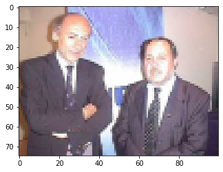

```python
acc = 0
with torch.no_grad():
  tt=40
  for iter, (bn, be, gs, label,rc) in enumerate(test_loader):
    r=rc[0][0]
    c=rc[0][1]
    prediction = model(bn, be, gs)
    im=np.zeros((r,c))
    count=0
    for x in range(0,r):
        for y in range(0,c):
            im[x,y]=prediction[count].argmax()#prediction[count][1].numpy()#prediction[count].argmax()
            count=count+1
    plt.imshow(im)
    plt.savefig('./data/res/image ('+str(tt)+') res.png')

    im=np.zeros((r,c))
    count=0
    for x in range(0,r):
        for y in range(0,c):
            im[x,y]=label[count].numpy()
            count=count+1
    plt.imshow(im)
    plt.savefig('./data/res/image ('+str(tt)+') gt.png')

    im=bn.reshape((r, c,3))
    plt.imshow(im)
    plt.savefig('./data/res/image ('+str(tt)+') rs.png')
    tt =tt +1
```

[figure not shown]

[figure not shown]

[figure not shown]

```python
im=Image.imread('./data/res/image (1) rs.png')
plt.figure(3)
plt.imshow(im)
plt.title("Source image")

im=Image.imread('./data/res/image (1) res.png')
plt.figure(1)
plt.imshow(im)
plt.title("Prediction")
im=Image.imread('./data/res/image (1) gt.png')
plt.figure(2)
plt.imshow(im)
plt.title("Ground Truth")
```

[figure not shown]

[figure not shown]

[figure not shown]

```python
im=Image.imread('./data/res/image (3) rs.png')
plt.figure(3)
plt.imshow(im)
plt.title("Source image")

im=Image.imread('./data/res/image (3) res.png')
plt.figure(1)
plt.imshow(im)
plt.title("Prediction")
im=Image.imread('./data/res/image (3) gt.png')
plt.figure(2)
plt.imshow(im)
plt.title("Ground Truth")
```

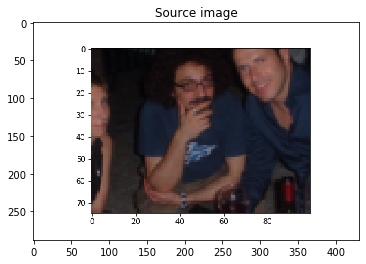

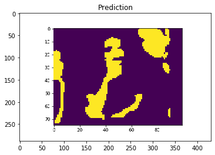

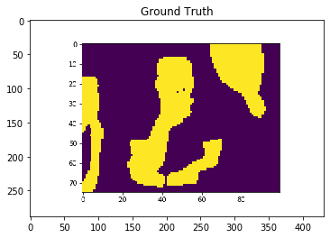

```python
im=Image.imread('./data/res/image (41) rs.png')
plt.figure(3)
plt.imshow(im)
plt.title("Source image")

im=Image.imread('./data/res/image (41) res.png')
plt.figure(1)
plt.imshow(im)
plt.title("Prediction")
im=Image.imread('./data/res/image (41) gt.png')
plt.figure(2)
plt.imshow(im)
plt.title("Ground Truth")
```